# App Exam 2

Author

4297

Published

March 19, 2025

### Comprehension Questions

#### Montoya and Hayes (2017) argue that it is problematic to rely solely on a series of hypothesis tests for mediation rather than focusing on the indirect effect. List and summarize these arguments. (3pts)

Montoya and Hayes discuss the different problems that arise when relying on the hypothesis testing for mediation. One the first problems discussed in that the more tests ran, the more Type I error there will be, so we reduce chance of this error with the series of hypothesis tests. Next, is that we do not need a significant total effect to have mediation in our model, so they step is not necessary. In addition, Looking for just teh indirect effect provides more power to the test.

(I am confused on why this article is considered an “Optional Reading” when we reference it frequently and need it to answer an exam question.)

##### 2. Centering in LMEMs

###### a. Discuss the role of centering in LMEMs. Why is it important to distinguish between within- and between-subject associations? (2 pts)

Centering in LMEMs is important to center within our groups (cluster mean centering) when we have within continuous predictors. When we have between-subject association we do not have to center around the groups because you are testing across different participants, not across the different levels of the predictors.

It is important to CMC continuous within predictors allows for different within-group effects compared to between-group effects.

##### b. Now suppose a researcher centers a predictor around the grand mean rather than the group mean, will any interpretational issues arise? Explain your reasoning. (2 pts)

Yes, interpreting the the centered grand mean will give you non-interpretable slopes. This would result in the same type of slope as just not centering at all, because you need to account the slopes of each group, rather than trying to make a slope for the three groups together.

#### 3. What factors should researchers consider when deciding whether to treat a variable (e.g., classrooms) as a fixed or random effect? (2 pts)

Our fixed effects are for all the participants to experience a certain level to or in other words, the population-level parameters. A random effect differs across the participants’ levels. Like the random slope of each individual will be different per participant based on that grouping level.

#### 4.

Katherine wants to understand the impact of social status on group discussion dynamics. Katherine decided to recruit a total of 80 participants who were randomly assigned to 20 discussion groups, with each group consisting of four members. Within each group, two participants were designated as high-status members and the other two as low-status members based on a pre-study questionnaire assessing leadership experience and perceived social dominance. Following a structured discussion on a controversial topic, each participant rated their enjoyment of the discussion on a 1–10 scale. Additionally, independent coders assessed each participant’s dominance level on a 1–5 scale based on their verbal and nonverbal behaviors during the discussion. The study sought to determine whether high-status individuals enjoyed the discussion more than low-status individuals, whether dominance moderated this effect, and whether the relationship between status and enjoyment differed at the individual vs. group level.

##### a. If Katherine ignored the group structure and treated all observations as independent, what statistical issues might arise? (1 pt)

This would violate Independence for her study. We know that the violation of Independence leads to inaccurate parameter estimates.

##### b. Suppose Katherine hypothesizes that dominance level significantly moderates the effect of status on enjoyment. Write out the corresponding lmer() model to capture this interaction. (1 pt)

lmer(enjoyment ~ status * dominance + (status|group_id), data)

##### c. How would you interpret a significant random slope for status in this study? (1 pt)

A significant random slope for status would be interpreted as the relationship between participants’ status, and discussion enjoyment varies across participants. We know this because the random slope is the difference in the slopes of each individual participant rather than the slope for all of those in one group and all of those in another.

## Data Analysis: Study A

### 1. Set up Global options

```r
options(conflicts.policy = "depends.ok")
library(tidyverse)
library(Matrix, exclude = c("expand", "pack", "unpack"))
library(lme4)
library(effects)
library(broom)
library(skimr)
library(car, exclude = c("recode", "some"))

theme_set(theme_classic())

path_data <- "hw/exam"
```

### 2.Read in and examine the data (“Acculturation.dat”).

Format your data so that your columns are in snake case and take care to properly class all columns. View univariate and bivariate statistics and plots. (3 pts)

```r
d <- read_delim(here::here(path_data, 'Acculturation.dat'), show_col_types = FALSE) |>
  janitor::clean_names() |>
  glimpse()
```

```
Rows: 192
Columns: 4
$ sub_id          <dbl> 1, 2, 3, 4, 5, 6, 7, 8, 9, 10, 11, 12, 13, 14, 15, 16,…
$ monthsin_us     <dbl> 10, 4, 8, 2, 17, 8, 2, 15, 10, 20, 12, 9, 23, 14, 3, 3…
$ english_fluency <dbl> 67, 78, 83, 66, 89, 58, 59, 76, 67, 63, 88, 84, 88, 86…
$ liking          <dbl> 97.12, 75.21, 91.86, 76.83, 88.09, 89.86, 71.83, 90.14…
```

```r
skim(d)
```

Data summary

| Name | d |
| --- | --- |
| Number of rows | 192 |
| Number of columns | 4 |
| _______________________ |  |
| Column type frequency: |  |
| numeric | 4 |
| ________________________ |  |
| Group variables | None |

**Variable type: numeric**

| skim_variable | n_missing | complete_rate | mean | sd | p0 | p25 | p50 | p75 | p100 | hist |
| --- | --- | --- | --- | --- | --- | --- | --- | --- | --- | --- |
| sub_id | 0 | 1 | 96.50 | 55.57 | 1.0 | 48.75 | 96.5 | 144.25 | 192 | ▇▇▇▇▇ |
| monthsin_us | 0 | 1 | 24.50 | 13.89 | 1.0 | 12.75 | 24.5 | 36.25 | 48 | ▇▇▇▇▇ |
| english_fluency | 0 | 1 | 75.34 | 9.49 | 57.0 | 67.75 | 76.0 | 83.00 | 99 | ▅▇▇▆▁ |
| liking | 0 | 1 | 84.23 | 11.11 | 50.1 | 77.71 | 86.1 | 91.96 | 100 | ▁▂▅▇▇ |

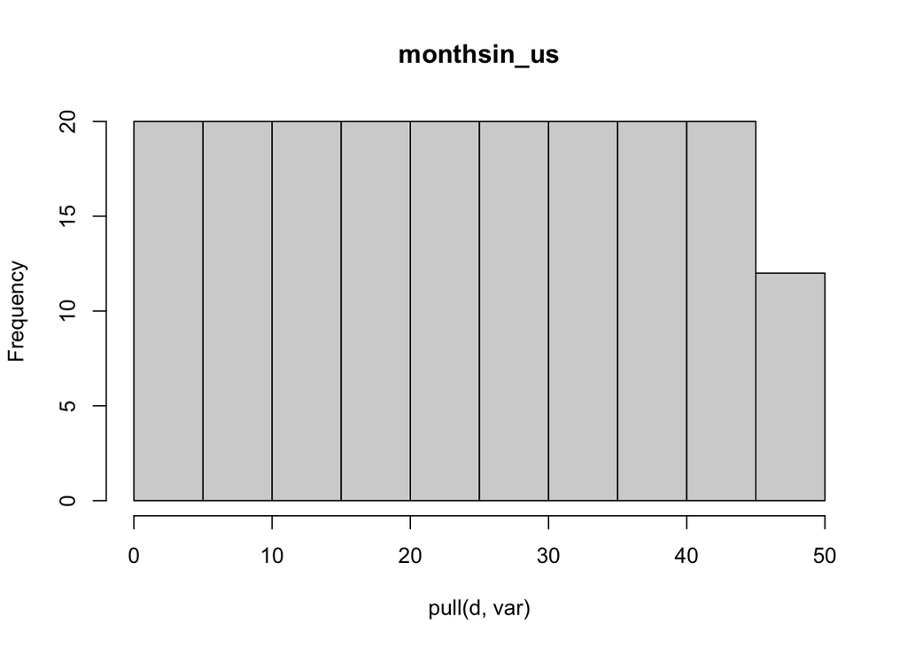

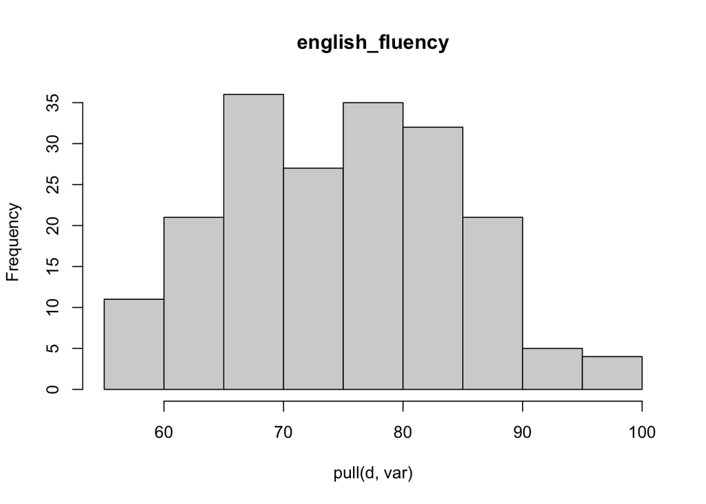

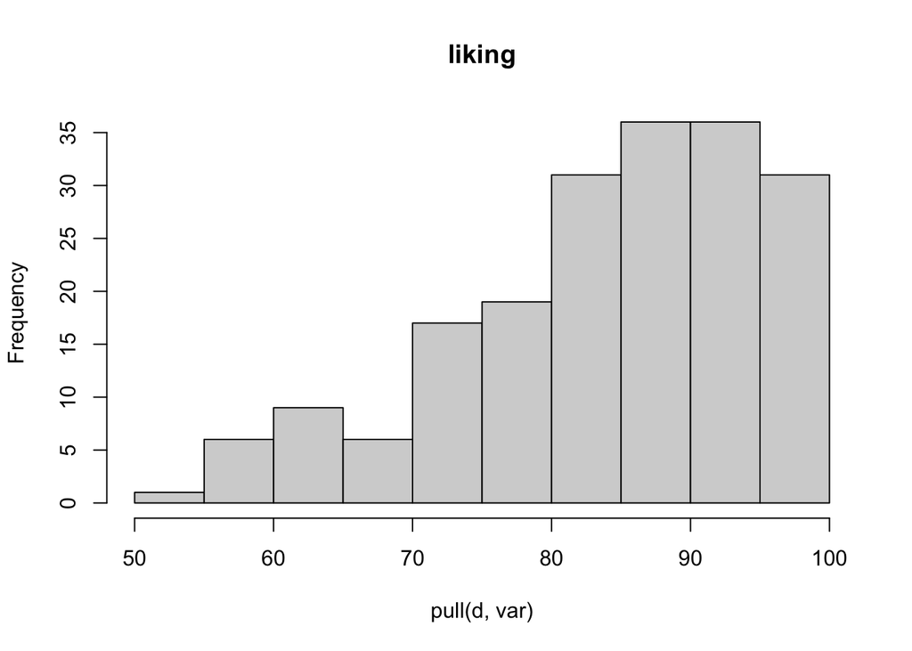

[output not shown]

[output cut: 13 more lines]

[output not shown]

```r
d |> select(-sub_id) |>
  select(where(is.numeric)) |>
  names() |>
  map(\(var) hist(d |> pull(var), main = var))
```

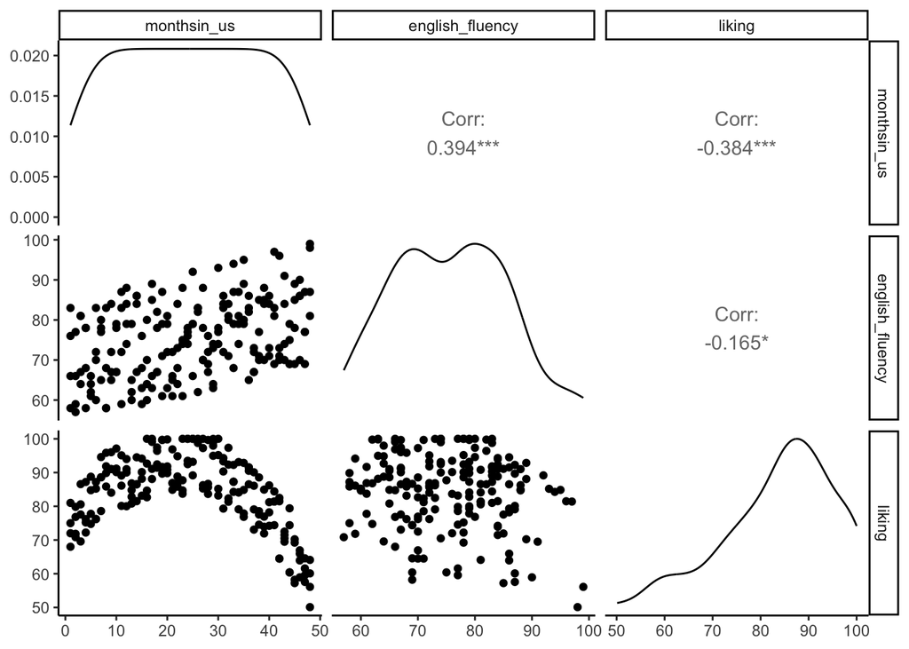

```r
d |>
  select(-sub_id) |>
  GGally::ggpairs()
```

### 2. Test and report if the relationship between “MonthsinUS” and “Liking” is non-linear (i.e.,quadratic), controlling for English Fluency.

```r
m1 <- lm(liking ~ monthsin_us + english_fluency, d)
m2 <- lm(liking ~ monthsin_us + I(monthsin_us^2) + english_fluency, d)
summary(m1)
```

```
Call:
lm(formula = liking ~ monthsin_us + english_fluency, data = d)

Residuals:
    Min      1Q  Median      3Q     Max
-26.603  -5.886   1.545   6.729  17.401

Coefficients:
                Estimate Std. Error t value Pr(>|t|)
(Intercept)     93.08196    6.06792  15.340  < 2e-16 ***
monthsin_us     -0.30175    0.05844  -5.163 6.12e-07 ***
english_fluency -0.01933    0.08550  -0.226    0.821
---
Signif. codes:  0 '***' 0.001 '**' 0.01 '*' 0.05 '.' 0.1 ' ' 1

Residual standard error: 10.31 on 189 degrees of freedom
Multiple R-squared:  0.1476,    Adjusted R-squared:  0.1385
F-statistic: 16.36 on 2 and 189 DF,  p-value: 2.801e-07
```

```r
summary(m2)
```

```
Call:
lm(formula = liking ~ monthsin_us + I(monthsin_us^2) + english_fluency,
    data = d)

Residuals:
     Min       1Q   Median       3Q      Max
-10.2787  -5.1673  -0.0531   4.9619  10.5931

Coefficients:
                  Estimate Std. Error t value Pr(>|t|)
(Intercept)      72.145146   3.671883  19.648   <2e-16 ***
monthsin_us       2.080899   0.127305  16.346   <2e-16 ***
I(monthsin_us^2) -0.048709   0.002509 -19.413   <2e-16 ***
english_fluency  -0.004097   0.049461  -0.083    0.934
---
Signif. codes:  0 '***' 0.001 '**' 0.01 '*' 0.05 '.' 0.1 ' ' 1

Residual standard error: 5.963 on 188 degrees of freedom
Multiple R-squared:  0.7163,    Adjusted R-squared:  0.7118
F-statistic: 158.2 on 3 and 188 DF,  p-value: < 2.2e-16
```

The relationship between Liking American Culture and Months in the US does have a significant non-linear relationship,$F(1,188) = 376.86, p < 0.001, R^2 = .72$ in the quadratic compared to the linear model $R^2 = .15$

### 3. Interpret the relationship between “MonthsinUS” and “Liking”

#### a. Magnitude of Effect

The quadratic effect of months in the US on liking American culture is initially positive but decreases in magnitude by approximately 0.10 units for each additional month spent in the US. #### b. Overall Effect The combined linear and quadratic effects of months spent in the US account for 72% of the variance in liking American culture, indicating a substantial overall impact. #### c. Months in US = 2.080899/(2*0.048709) = 21 months (21.36 so round down to 21 months).

#### d. Recenter monthsin_us

```r
d <- d |>
  mutate(monthsin_us_c = monthsin_us - 21.36)
m2_b <- lm(liking ~ monthsin_us_c + I(monthsin_us_c^2) + english_fluency, d)
summary(m2_b)
```

```
Call:
lm(formula = liking ~ monthsin_us_c + I(monthsin_us_c^2) + english_fluency,
    data = d)

Residuals:
     Min       1Q   Median       3Q      Max
-10.2787  -5.1673  -0.0531   4.9619  10.5931

Coefficients:
                     Estimate Std. Error t value Pr(>|t|)
(Intercept)         9.437e+01  3.732e+00  25.289   <2e-16 ***
monthsin_us_c       3.755e-05  3.721e-02   0.001    0.999
I(monthsin_us_c^2) -4.871e-02  2.509e-03 -19.413   <2e-16 ***
english_fluency    -4.097e-03  4.946e-02  -0.083    0.934
---
Signif. codes:  0 '***' 0.001 '**' 0.01 '*' 0.05 '.' 0.1 ' ' 1

Residual standard error: 5.963 on 188 degrees of freedom
Multiple R-squared:  0.7163,    Adjusted R-squared:  0.7118
F-statistic: 158.2 on 3 and 188 DF,  p-value: < 2.2e-16
```

### 4.

For international students who have stayed in the US for three years, the effect for each additional month in the US on liking American culture is negative, with each additional month decreasing liking by 1.42 units, while controlling for English fluency.

### 5. Publication Quality Graph

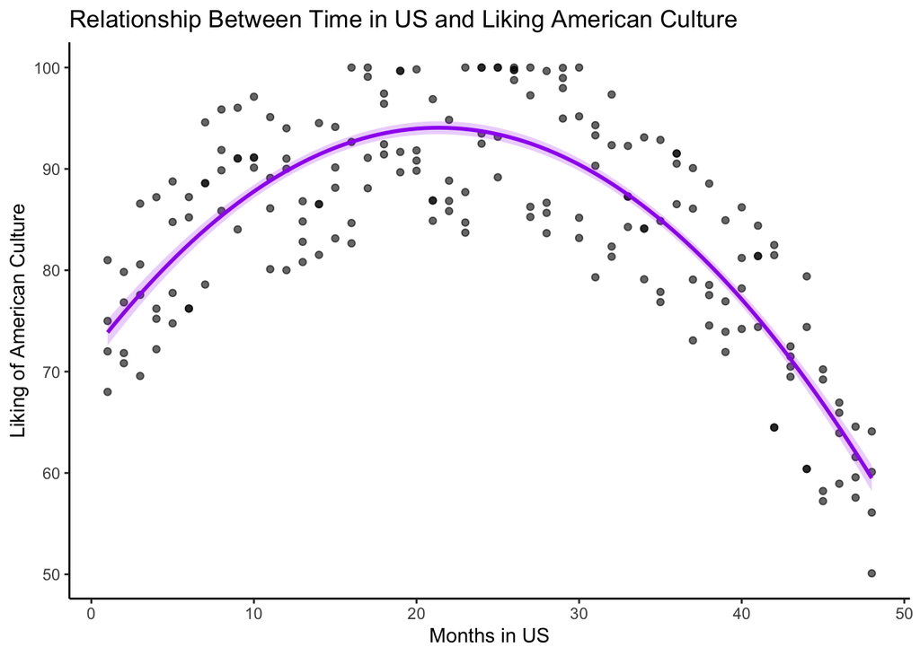

```r
d_graph <- expand_grid(
  monthsin_us = seq(min(d$monthsin_us), max(d$monthsin_us), length.out = 100),
  english_fluency = mean(d$english_fluency)
)

preds <- predict(m2, newdata = d_graph, se.fit = TRUE) |>
  as_tibble() |>
  mutate(
    upper = fit + se.fit,
    lower = fit - se.fit
  ) |>
  bind_cols(d_graph)

ggplot() +
  geom_point(data = d, aes(x = monthsin_us, y = liking), alpha = 0.6) +
  geom_ribbon(data = preds, aes(x = monthsin_us, ymin = lower, ymax = upper),
              alpha = 0.2, fill = "purple") +
  geom_line(data = preds, aes(x = monthsin_us, y = fit),
            color = "purple", linewidth = 1) +
  labs(
    title = "Relationship Between Time in US and Liking American Culture",
    x = "Months in US",
    y = "Liking of American Culture")
```

## Data Analysis B

### Read in Data

```r
d2 <- read_delim(here::here(path_data, 'WM.dat'), show_col_types = FALSE) |>
  janitor::clean_names() |>
  glimpse()
```

```
Rows: 38
Columns: 4
$ sub_id  <dbl> 1, 2, 3, 4, 5, 6, 7, 8, 9, 10, 11, 12, 13, 14, 15, 16, 17, 18,…
$ group   <dbl> 0, 0, 0, 0, 0, 0, 0, 0, 0, 0, 0, 0, 0, 0, 0, 0, 0, 0, 0, 1, 1,…
$ pre_wm  <dbl> 2.95, 2.15, 1.05, 1.45, 2.85, 3.15, 1.75, 1.75, 1.55, 2.05, 1.…
$ post_wm <dbl> 5.14, 3.49, 2.93, 3.10, 4.75, 4.30, 3.10, 4.29, 2.87, 3.99, 2.…
```

```r
skim(d2)
```

Data summary

| Name | d2 |
| --- | --- |
| Number of rows | 38 |
| Number of columns | 4 |
| _______________________ |  |
| Column type frequency: |  |
| numeric | 4 |
| ________________________ |  |
| Group variables | None |

**Variable type: numeric**

| skim_variable | n_missing | complete_rate | mean | sd | p0 | p25 | p50 | p75 | p100 | hist |
| --- | --- | --- | --- | --- | --- | --- | --- | --- | --- | --- |
| sub_id | 0 | 1 | 19.50 | 11.11 | 1.00 | 10.25 | 19.50 | 28.75 | 38.00 | ▇▇▇▇▇ |
| group | 0 | 1 | 0.50 | 0.51 | 0.00 | 0.00 | 0.50 | 1.00 | 1.00 | ▇▁▁▁▇ |
| pre_wm | 0 | 1 | 2.79 | 0.89 | 1.05 | 2.15 | 2.92 | 3.30 | 4.50 | ▃▃▇▆▂ |
| post_wm | 0 | 1 | 4.90 | 1.32 | 2.16 | 4.03 | 5.06 | 5.79 | 7.96 | ▃▅▇▅▂ |

```r
d2 <- d2 |>
  mutate(group_c = if_else(group == 0, -.5, .5))
```

### Run the Model

```r
m_ancova <- lm(post_wm ~ group_c + pre_wm, d2)
summary(m_ancova)
```

```
Call:
lm(formula = post_wm ~ group_c + pre_wm, data = d2)

Residuals:
     Min       1Q   Median       3Q      Max
-1.08255 -0.48330  0.07757  0.26660  1.00556

Coefficients:
            Estimate Std. Error t value Pr(>|t|)
(Intercept)   1.8689     0.3898   4.794 2.98e-05 ***
group_c       0.6382     0.2397   2.663   0.0116 *
pre_wm        1.0838     0.1358   7.981 2.17e-09 ***
---
Signif. codes:  0 '***' 0.001 '**' 0.01 '*' 0.05 '.' 0.1 ' ' 1

Residual standard error: 0.5526 on 35 degrees of freedom
Multiple R-squared:  0.8348,    Adjusted R-squared:  0.8254
F-statistic: 88.44 on 2 and 35 DF,  p-value: 2.065e-14
```

```r
effectsize::eta_squared(m_ancova)
```

```
# Effect Size for ANOVA (Type I)

Parameter | Eta2 (partial) |       95% CI
-----------------------------------------
group_c   |           0.76 | [0.64, 1.00]
pre_wm    |           0.65 | [0.48, 1.00]

- One-sided CIs: upper bound fixed at [1.00].
```

In this study we examined how working memory training affects children from ages 6-7, versus adolescents who are ages 14-15. Researchers hypothesized that adolescents would show greater improvement due to prefrontal cortex development during this period. Participants completed pre-tests of visuospatial working memory, underwent 25 daily training sessions, then completed post-tests to measure improvement.

The ANCOVA model tested the effect of group on post-test working memory capacity, controlling for pre-test working memory capacity. In this model, Adolescents showed a significantly greater increase in post_wm compared to children, $b=0.64, t(35)=2.66, p=.012,\eta^2_p =.76$.This means that for a one-unit increase in group, from children to adolescent, Post-test measure of Visuospatial working memory increases by 0.64 units, holding pre-test measure of Visuospatial working memory constant. Pre-test working memory capacity was a significant predictor of post_wm, $b=1.08, t(35)=7.98, p<.001, \eta^2_p=0.65$. For a one-unit increase in pre-test measure of Visuospatial working memory increases by , post-test measure of Visuospatial working memory increases by increases by 1.08 units, holding group constant.

## Data Analysis C

### Read in Data

```r
d3 <- read_delim(here::here(path_data, 'Classroom.dat'), show_col_types = FALSE) |>
  janitor::clean_names() |>
  glimpse()
```

```
Rows: 1,800
Columns: 5
$ class_id    <dbl> 1, 1, 1, 1, 1, 1, 1, 1, 1, 1, 1, 1, 1, 1, 1, 1, 1, 1, 1, 1…
$ student     <dbl> 1, 2, 3, 4, 5, 6, 7, 8, 9, 10, 11, 12, 13, 14, 15, 16, 17,…
$ cond        <dbl> 1, 2, 1, 2, 1, 2, 1, 2, 1, 2, 1, 2, 1, 2, 1, 2, 1, 2, 1, 2…
$ confidence  <dbl> 6, 7, 5, 6, 4, 7, 1, 6, 5, 7, 2, 4, 6, 6, 4, 7, 6, 5, 3, 6…
$ performance <dbl> 9.166790, 19.216017, 14.380746, 24.660361, 16.792046, 26.2…
```

```r
skim(d3)
```

Data summary

| Name | d3 |
| --- | --- |
| Number of rows | 1800 |
| Number of columns | 5 |
| _______________________ |  |
| Column type frequency: |  |
| numeric | 5 |
| ________________________ |  |
| Group variables | None |

**Variable type: numeric**

| skim_variable | n_missing | complete_rate | mean | sd | p0 | p25 | p50 | p75 | p100 | hist |
| --- | --- | --- | --- | --- | --- | --- | --- | --- | --- | --- |
| class_id | 0 | 1 | 30.50 | 17.32 | 1 | 15.75 | 30.50 | 45.25 | 60 | ▇▇▇▇▇ |
| student | 0 | 1 | 15.50 | 8.66 | 1 | 8.00 | 15.50 | 23.00 | 30 | ▇▇▇▇▇ |
| cond | 0 | 1 | 1.50 | 0.50 | 1 | 1.00 | 1.50 | 2.00 | 2 | ▇▁▁▁▇ |
| confidence | 0 | 1 | 5.29 | 1.60 | 0 | 4.00 | 5.00 | 6.00 | 10 | ▁▅▇▅▁ |
| performance | 0 | 1 | 18.40 | 6.64 | 0 | 13.81 | 18.23 | 22.85 | 50 | ▂▇▆▁▁ |

#### Center IV

```r
d3 <- d3 |>
  mutate(cond_c = if_else(cond == 1, -.5, .5))
```

#### Graph GGplot

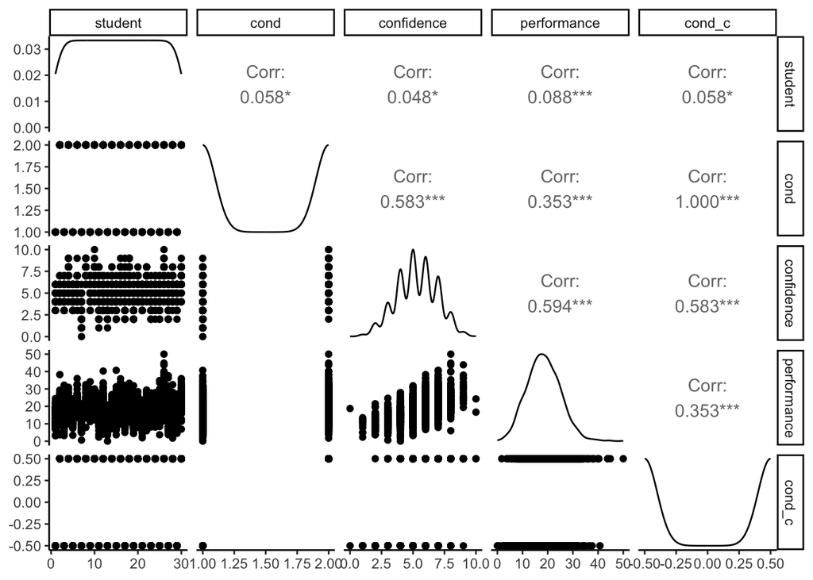

```r
d3 |>
  select(-class_id) |>
  GGally::ggpairs()
```

### Test the hypothesis that students assigned to work on tangrams for 30 minutes will have better performance on the standardized math test than students assigned to do regular homework

#### a.

lmer(performance ~ cond_c + (cond_c|class_id), d3) Level 1:
$$\text{perfomance}_{ij} =\beta_{0j} + \beta_{1j}(\text{cond_c}_{ij}) + e_{ij}$$
Level 2:
$$\beta_{0j} = \gamma_{00} + u_{0j}$$
$$\beta_{1j} = \gamma_{10}(\text{cond_c}_{ij}) + u_{1j}$$
$$\text{performance}_{ij} = \gamma_{00} + \gamma_{10}(\text{cond_c}_{ij}) + u_{0j} + u_{1j}(\text{cond_c}_{ij}) + e_{ij}$$

#### b. Create a model

```r
m_c <- lmer(performance ~ cond_c + (cond_c|class_id), d3)
summary(m_c)
```

```
Linear mixed model fit by REML ['lmerMod']
Formula: performance ~ cond_c + (cond_c | class_id)
   Data: d3

REML criterion at convergence: 11676.9

Scaled residuals:
    Min      1Q  Median      3Q     Max
-3.0751 -0.7096 -0.0249  0.6210  4.6157

Random effects:
 Groups   Name        Variance Std.Dev. Corr
 class_id (Intercept)  0.2759  0.5252
          cond_c       2.3658  1.5381   1.00
 Residual             37.7779  6.1464
Number of obs: 1800, groups:  class_id, 60

Fixed effects:
            Estimate Std. Error t value
(Intercept)  18.4011     0.1600  115.04
cond_c        4.6903     0.3513   13.35

Correlation of Fixed Effects:
       (Intr)
cond_c 0.240
```

```r
Anova(m_c, type =3, test = "F")
```

```
Analysis of Deviance Table (Type III Wald F tests with Kenward-Roger df)

Response: performance
                  F Df Df.res    Pr(>F)
(Intercept) 13234.0  1     59 < 2.2e-16 ***
cond_c        178.3  1     59 < 2.2e-16 ***
---
Signif. codes:  0 '***' 0.001 '**' 0.01 '*' 0.05 '.' 0.1 ' ' 1
```

Students that worked with tangrams scored significantly higher on the standardized math test compared to students who did regular homework, with an estimated increase of 4.69 points (F(1,59) =178.3, p < .001)

#### Mediation Model

lmer(performance ~ cond_c * confidence + (cond_c*confidence|class_id), d3) #### a. Level 1 Model
$$\text{performance}_{ij} = \beta_{0j} + \beta_{1j}(\text{cond_c}_{ij}) + \beta_{2j}(\text{confidence}_{ij}) + \beta_{3j}(\text{cond_c}_{ij}*\text{confidence}_{ij}) + e_{ij}$$
#### b. Level 2 Model
$$\beta_{0j} = \gamma_{00} + u_{0j}$$
$$\beta_{1j} = \gamma_{10}+ u_{1j}$$
$$\beta_{2j} = \gamma_{20} + u_{2j}$$
$$\beta_{3j} = \gamma_{30} + u_{3j}$$
#### c. Combined model
$$\text{performance}_{ij} = \gamma_{00} + \gamma_{10}(\text{cond_c}_{ij}) + \gamma_{20}(\text{confidence}_{ij}) + \gamma_{30}(\text{cond_c}_{ij} * \text{confidence}_{ij}) + u_{0j} + u_{1j}(\text{cond_c}_{ij}) + u_{2j}(\text{confidence}_{ij}) + u_{3j}(\text{cond_c}_{ij} * \text{confidence}_{ij}) + e_{ij}$$

#### 4.

In question 2 we have a covariance of 1 additional parameter between u_0j and u_1j.This is for the random intercept (u_0j) and the random slope (u_1j). However, it seems that we have a correlation of 1.00, which should be impossible. So this makes me believe that it is the cause of the fake data or possibly that groups are not exactly nested correctly for our data. The total number of parameters for the model would be 6.

### Report ChatGPT/Other LLMs

I have not used ChatGPT on this Exam.

### How long did this assingment take you?

12 hours.